# Question

Consider the $L$-system (and angle) defined below:

- Start: `X`
- Rules:  
  `F > FF`  
  `X > F[+XXF+F][-XXF-F]FXX`
- Number of recursions (number of iterations):
  - 4
- Angle
  - 30°

Please use [this L-system string generator](https://chadworley.github.io/Lsys_string_gen.html) along with [Turbo Turtle](https://scratch.mit.edu/projects/1225522722/editor/) to generate the pattern.

With Turbo Turtle, you’ll want to “See Inside” to adjust the initial $x$, initial $y$, and `DISTANCE` variable to get the pattern centered and scaled. You’ll also want to turn on Turbo Mode (in the Edit drop-down menu).

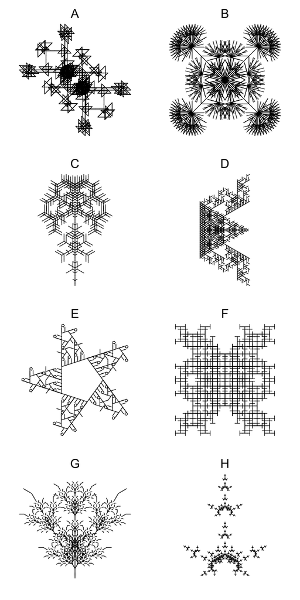

## Answerlist

- A
- B
- C
- D
- E
- F
- G
- H

# Solution

The correct pattern is pattern G.

In case you’re interested in the parameters of the other patterns shown:

## Pattern A

- Start: `A++A++A++A`
- Rules:  
  `A > B-CAC-B`  
  `B > AB-BA`  
  `C > CC`
- Number of recursions (number of iterations):
  - 5
- Angle
  - 135

## Pattern B

- Start: `[A]------------[A]`
- Rules:  
  `A > [---BC][+++BC]`  
  `B > [--AC][++AC]`  
  `C > F[-BA][+BA]`  
  `F > FF`
- Number of recursions (number of iterations):
  - 5
- Angle
  - 15

## Pattern C

- Start: `A`
- Rules:  
  `A > AA[-B][+B]B`  
  `B > B[-ABC][+ABC]`  
  `C > C[-CBA][+CBA]`
- Number of recursions (number of iterations):
  - 4
- Angle
  - 60

## Pattern D

- Start: `B---A`
- Rules:  
  `A > A[-AB]A`  
  `B > B[+BA]B`
- Number of recursions (number of iterations):
  - 5
- Angle
  - 60

## Pattern E

- Start: `A`
- Rules:  
  `A > B+B+B+B+B`  
  `B > [-CCA]BB`  
  `C > CC`
- Number of recursions (number of iterations):
  - 5
- Angle
  - 72

## Pattern F

- Start: `A++A`
- Rules:  
  `A > AB[-A][+A]`  
  `B > A`
- Number of recursions (number of iterations):
  - 6
- Angle
  - 90

## Pattern G

- Start: `X`
- Rules:  
  `F > FF`  
  `X > F[+XXF+F][-XXF-F]FXX`
- Number of recursions (number of iterations):
  - 4
- Angle
  - 30

## Pattern H

- Start: `A`
- Rules:  
  `A > X[-A][+A]AA`  
  `X > XX`
- Number of recursions (number of iterations):
  - 5
- Angle
  - 60

# Meta-information

extype: schoice exsolution: 00000010 exname: lsys_pattern